# 1US0 TYR Ring_0_0.3_12_Density

## Sample=1us0-a:39:cd1-a:39:cg-a:39:cd2

| pdb_code | central atom | ca density | parallel atom | pa density | planar atom | pl density |
| --- | --- | --- | --- | --- | --- | --- |
| 1us0 | [14.84, -3.41, 38.3] | 228.8276 | [14.02, -2.84, 37.31] | 218.9281 | [14.64, -2.45, 36.13] | 212.654 |

## 3d view of density

xyz

yzx

zxy

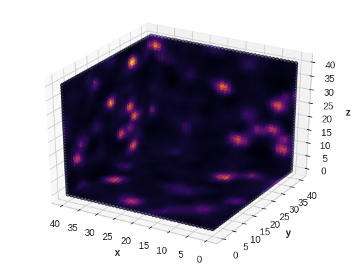

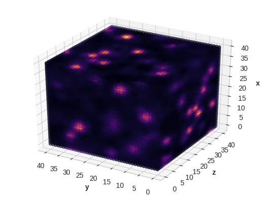

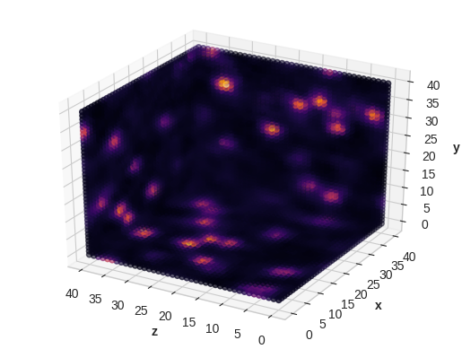

## Histograms of densities

Matrix Histogram

Entire Density Histogram

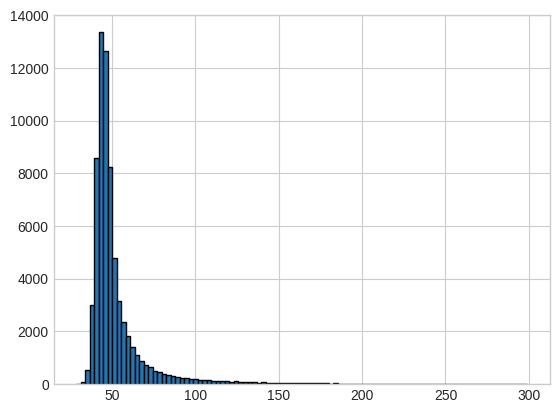

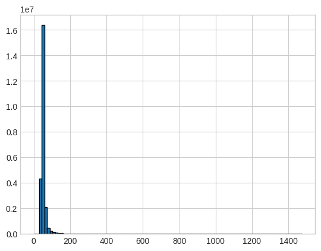

## Slices along x,y and z

Sliced x-wise

Sliced y-wise

Sliced z-wise

0/41

0/41

0/41

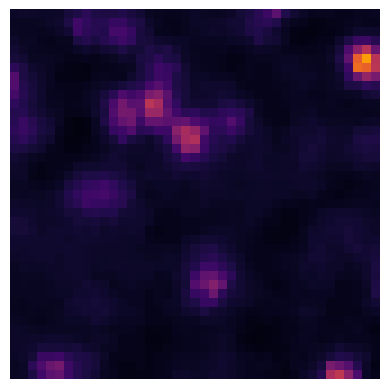

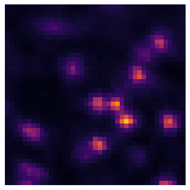

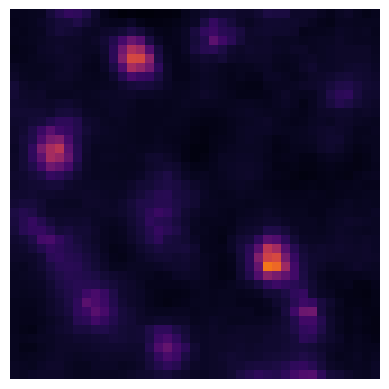

1/41

1/41

1/41

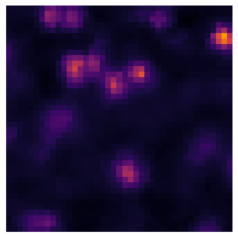

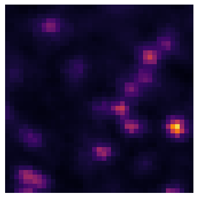

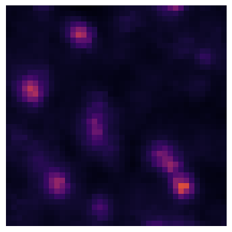

2/41

2/41

2/41

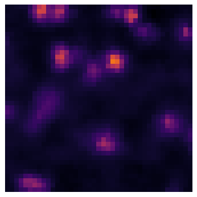

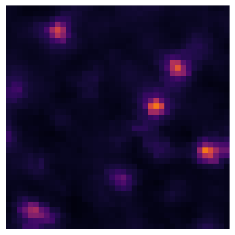

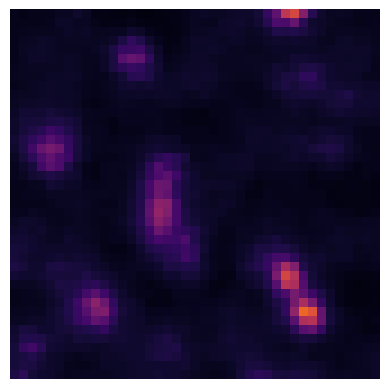

3/41

3/41

3/41

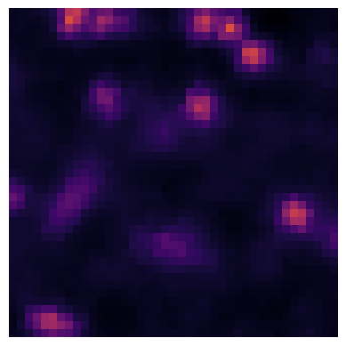

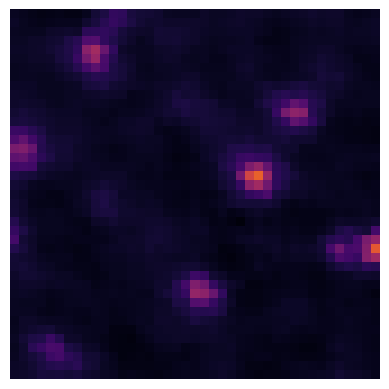

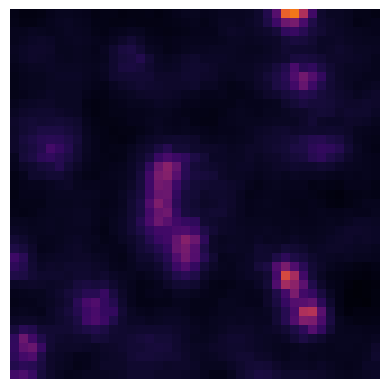

4/41

4/41

4/41

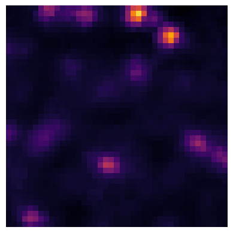

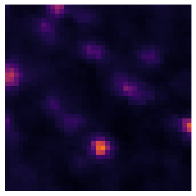

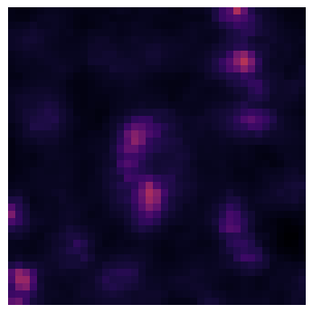

5/41

5/41

5/41

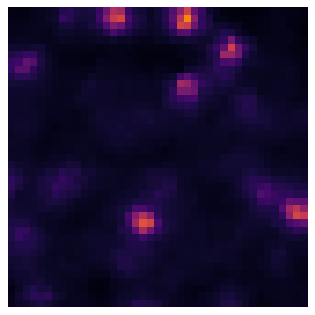

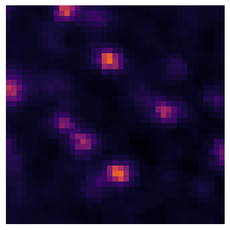

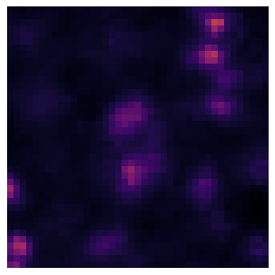

6/41

6/41

6/41

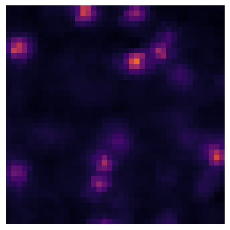

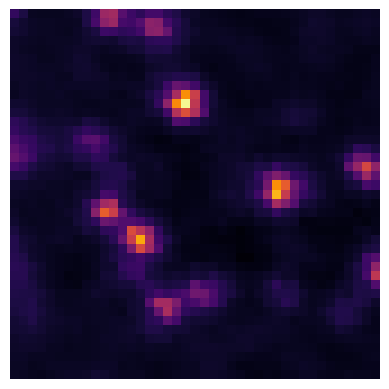

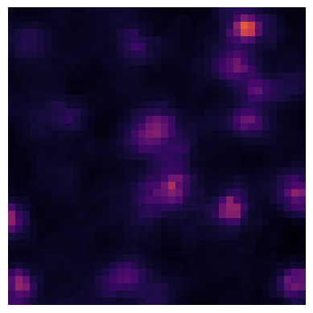

7/41

7/41

7/41

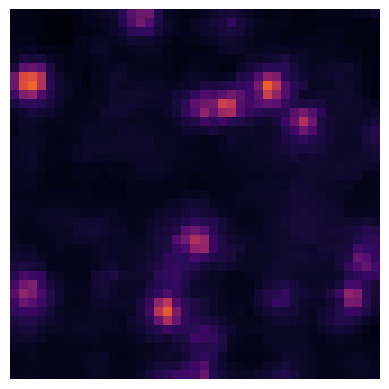

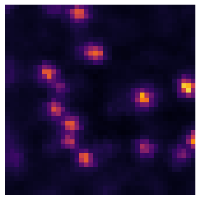

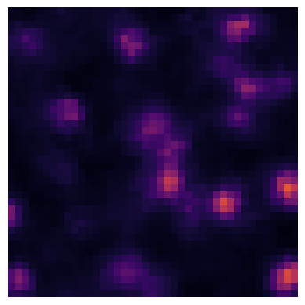

8/41

8/41

8/41

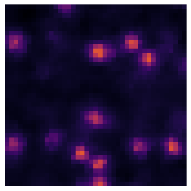

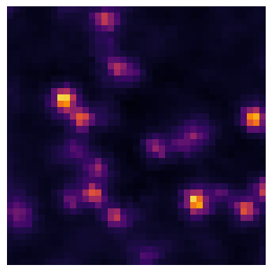

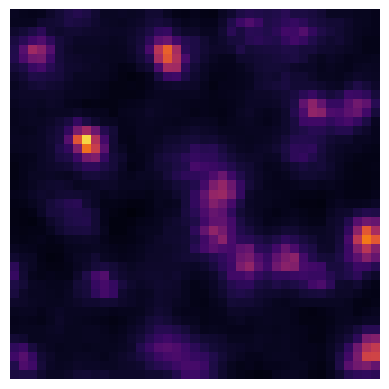

9/41

9/41

9/41

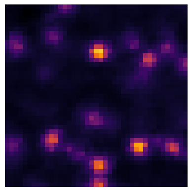

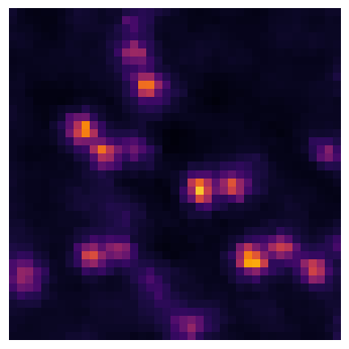

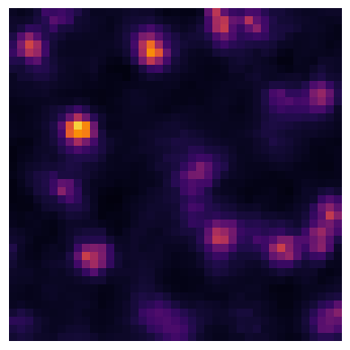

10/41

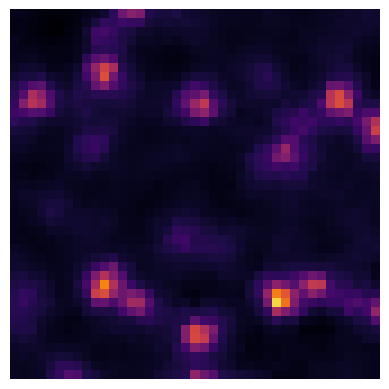

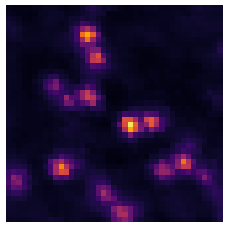

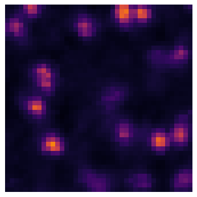

11/41

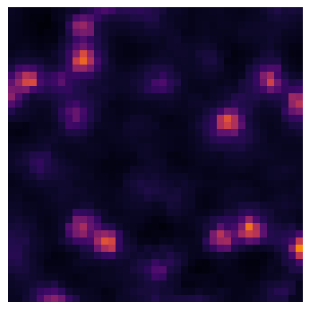

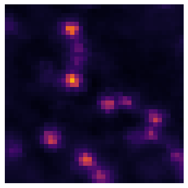

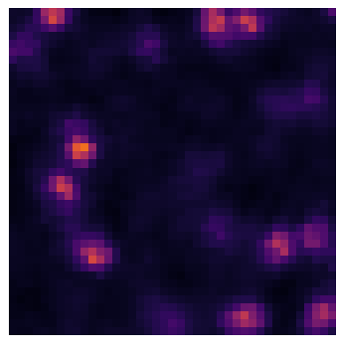

12/41

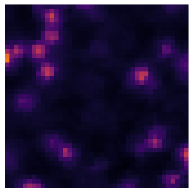

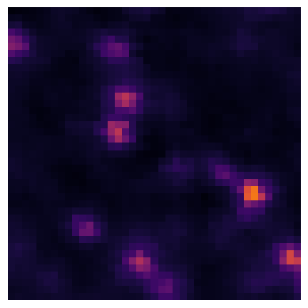

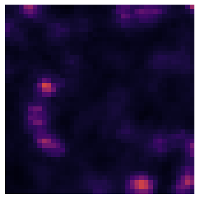

13/41

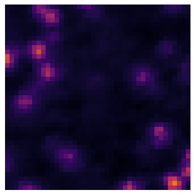

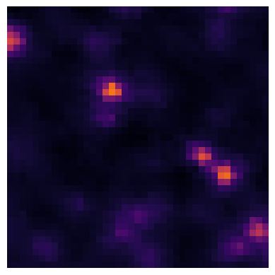

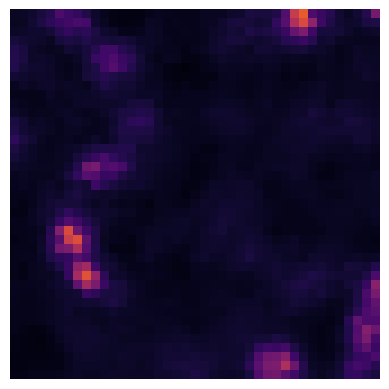

14/41

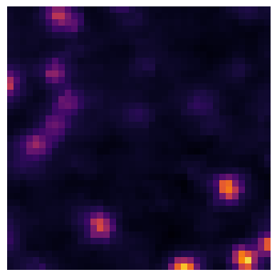

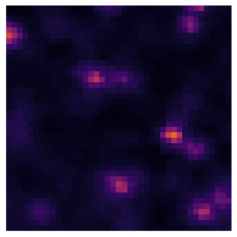

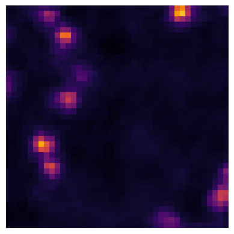

15/41

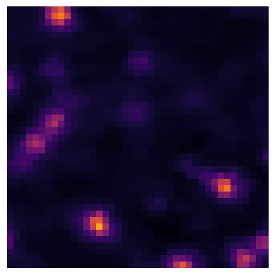

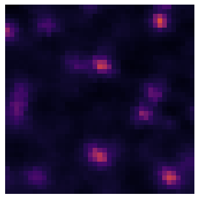

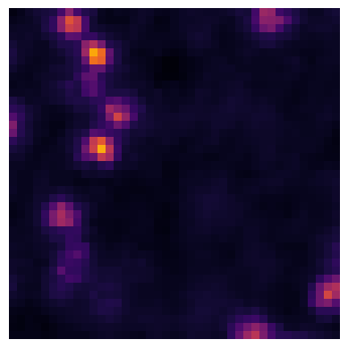

16/41

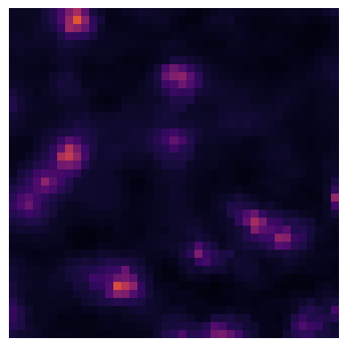

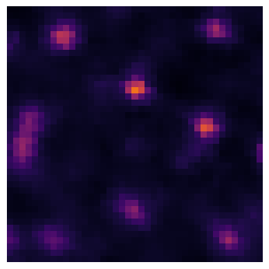

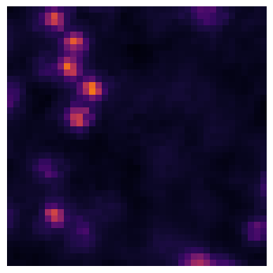

17/41